# Progress Memo 1

Final Project  
Data Science 2 with R (STAT 301-2)

Author

Cassie Lee

Published

January 31, 2024

**Github Repo Link**

[Cassie Lee’s Final Project Memo](https://github.com/stat301-2-2024-winter/final-project-2-cassielee2025.git)

## Prediction problem

The developmental origins of health and disease (DOHaD) is a framework that seeks to link exposures to environmental stressors during windows of susceptibility to the development of non-communicable diseases later in life(Lacagnina 2019). Birth weight has historically been used as an indicator of adverse early life exposures to environmental stressors due to the development of the field of DOHaD and the relative ease of collecting birth weight data(Hanson 2015). Low birth weight is a risk factor for developing non-communicable diseases later in life such as cardiovascular diseases, metabolic diseases, and kidney diseases(Bianchi and Restrepo 2022).

Lacagnina, Salvatore. 2019. “The Developmental Origins of Health and Disease (DOHaD).” *American Journal of Lifestyle Medicine* 14 (1): 47–50. https://doi.org/10.1177/1559827619879694.

Hanson, M. 2015. “The Birth and Future Health of DOHaD.” *Journal of Developmental Origins of Health and Disease* 6 (5): 434–37. https://doi.org/10.1017/S2040174415001129.

Bianchi, Maria Eugenia, and Jaime M. Restrepo. 2022. “Low Birthweight as a Risk Factor for Non-Communicable Diseases in Adults.” *Frontiers in Medicine* 8. https://www.frontiersin.org/articles/10.3389/fmed.2021.793990.

The objective of this prediction problem is to create a model to predict the birth weight of an infant given a certain set of characteristics. This is a regression problem. Having a prediction model for this problem can be useful in providing insights to eventually developing an inferential question that identifies the most important factors associated with birth weight.

I had originally wanted to do a classification problem to predict whether or not an infant would be classified as being born with a low birth weight, however, upon inspection of the target variable, there were only about 10% of observations that were considered low birth weight.

This is interesting to me because I am interested in how environmental exposures related to climate change during windows of susceptibility affect birth weight. However, due to constraints on the data I was able to find, I am only focusing on the birth weight aspect for this prediction problem.

## Data source

The original dataset was downloaded off the Kaggle dataset, US births (2018)[^1], by Amol Deshmukh. Deshmukh created this dataset from the raw 2018 natality file available from the Vital Statistics Online Data Portal[^2].

<sup>1</sup> [Kaggle dataset](https://www.kaggle.com/datasets/des137/us-births-2018/data)

<sup>2</sup> [CDC Vital Statistics Online Data Portal](https://www.cdc.gov/nchs/data_access/vitalstatsonline.htm#Tools)

<sup>3</sup> [Kaggle competition](https://www.kaggle.com/competitions/prediction-interval-competition-i-birth-weight/discussion/459133)

I searched Kaggle for a dataset relating to birth weight and found the Kaggle competition, Prediction interval competition I: Birth weight[^3] by Carl McBride Ellis. The dataset from this Kaggle competition cited the US births (2018) Kaggle dataset as its source. I downloaded the US births (2018) Kaggle dataset to have access to the the full dataset and have more control over the amount of observations I used for exploratory data analysis, the training data, and the testing data. From the dataset I downloaded, I selected the same variables that were used in the Kaggle competition so there would be congruence between the competition dataset and my dataset. I am assuming that the variables selected by Ellis are an appropriate mix of variables to use in a prediction problem.

## Data quality check

The dataset I downloaded has over 3 million observations, corresponding to all US births in 2018, so I randomly sampled 60,000 observations for use in this project. I will use 20,000 observations for exploratory data analysis and split the remaining 40,000 observations between training and testing sets.

Before randomly sampling the data, I checked the data codebook and recoded all missing, unknown, or not applicable values for each variable as `NA`. I then removed all incomplete observations and randomly sampled the data.

I successfully read in the data, subsetted variables, and dropped observations with missing values:

```r
birth_original <- read_csv(here("data/US_births(2018).csv")) %>%
  janitor::clean_names()

# create list of variables to select
vars <- c(
  "dbwt",
  "attend",
  "bfacil",
  "bmi",
  "cig_0",
  "dlmp_mm",
  "dmar",
  "dob_mm",
  "dob_tt",
  "dob_wk",
  "fagecomb",
  "feduc",
  "illb_r",
  "ilop_r",
  "ilp_r",
  "ld_indl",
  "mager",
  "mbstate_rec",
  "meduc",
  "m_ht_in",
  "no_infec",
  "no_mmorb",
  "no_risks",
  "pay",
  "pay_rec",
  "precare",
  "previs",
  "priordead",
  "priorlive",
  "priorterm",
  "p_wgt_r",
  "rdmeth_rec",
  "restatus",
  "rf_cesar",
  "rf_cesarn",
  "sex",
  "wtgain"
)

# filter out incomplete observations
birth_complete <- birth_original %>%
  select(all_of(vars)) %>%
  mutate(
    dbwt = na_if(dbwt, 9999),
    attend = na_if(attend, 9),
    bfacil = na_if(bfacil, 9),
    bmi = na_if(bmi, 99.9),
    cig_0 = na_if(cig_0, 99),
    dlmp_mm = na_if(dlmp_mm, 99),
    dob_tt = na_if(dob_tt, 9999),
    fagecomb = na_if(fagecomb, 99),
    feduc = na_if(feduc, 9),
    illb_r = na_if(illb_r, 888),
    illb_r = na_if(illb_r, 999),
    ilop_r = na_if(ilop_r, 888),
    ilop_r = na_if(ilop_r, 999),
    ilp_r = na_if(ilp_r, 888),
    ilp_r = na_if(ilp_r, 999),
    ld_indl = na_if(ld_indl, "U"),
    mbstate_rec = na_if(mbstate_rec, 3),
    meduc = na_if(meduc, 9),
    m_ht_in = na_if(m_ht_in, 99),
    no_infec  = na_if(no_infec, 9),
    no_mmorb = na_if(no_mmorb, 9),
    no_risks = na_if(no_risks, 9),
    pay  = na_if(pay, 9),
    pay_rec = na_if(pay_rec, 9),
    precare = na_if(precare, 99),
    previs = na_if(previs, 99),
    priordead = na_if(priordead, 99),
    priorlive = na_if(priorlive, 99),
    priorterm = na_if(priorterm, 99),
    p_wgt_r = na_if(p_wgt_r, 999),
    rdmeth_rec = na_if(rdmeth_rec, 9),
    rf_cesar = na_if(rf_cesar, "U"),
    # convert number of cesarean to from character to numeric
    rf_cesarn = as.numeric(rf_cesarn),
    rf_cesarn = na_if(rf_cesarn, 99),
    wtgain = na_if(wtgain, 99)
  ) %>%
  drop_na()

# show proper read in
show_birth_read_in <- birth_complete %>%
  slice(1:10)
```

| dbwt | attend | bfacil | bmi | cig_0 | dlmp_mm | dmar | dob_mm | dob_tt | dob_wk | fagecomb | feduc | illb_r | ilop_r | ilp_r | ld_indl | mager | mbstate_rec | meduc | m_ht_in | no_infec | no_mmorb | no_risks | pay | pay_rec | precare | previs | priordead | priorlive | priorterm | … |
| --- | --- | --- | --- | --- | --- | --- | --- | --- | --- | --- | --- | --- | --- | --- | --- | --- | --- | --- | --- | --- | --- | --- | --- | --- | --- | --- | --- | --- | --- | --- |
| 3657 | 1 | 1 | 30.7 | 0 | 4 | 1 | 1 | 1227 | 2 | 31 | 3 | 16 | 33 | 16 | N | 30 | 1 | 6 | 66 | 1 | 1 | 1 | 2 | 2 | 3 | 8 | 0 | 1 | 2 | … |
| 4130 | 1 | 1 | 25.7 | 0 | 4 | 1 | 1 | 155 | 7 | 26 | 4 | 24 | 51 | 24 | N | 25 | 1 | 4 | 63 | 1 | 1 | 1 | 1 | 1 | 2 | 9 | 0 | 2 | 1 | … |
| 4210 | 1 | 1 | 23.9 | 0 | 3 | 1 | 1 | 1000 | 1 | 41 | 4 | 19 | 34 | 19 | N | 38 | 1 | 7 | 66 | 1 | 1 | 1 | 2 | 2 | 2 | 14 | 0 | 2 | 2 | … |
| 4130 | 1 | 1 | 34.0 | 0 | 3 | 2 | 1 | 2240 | 7 | 27 | 2 | 12 | 21 | 12 | N | 24 | 1 | 4 | 61 | 1 | 1 | 0 | 1 | 1 | 2 | 10 | 1 | 3 | 1 | … |
| 3410 | 1 | 1 | 28.2 | 0 | 4 | 1 | 1 | 1243 | 1 | 45 | 6 | 42 | 13 | 13 | N | 41 | 1 | 7 | 66 | 1 | 1 | 1 | 2 | 2 | 3 | 12 | 0 | 1 | 2 | … |
| 3730 | 1 | 1 | 21.6 | 0 | 4 | 1 | 1 | 2101 | 2 | 29 | 6 | 28 | 42 | 28 | N | 29 | 1 | 6 | 65 | 1 | 1 | 0 | 5 | 4 | 2 | 10 | 0 | 1 | 2 | … |
| 3409 | 1 | 1 | 33.7 | 0 | 3 | 1 | 1 | 1905 | 5 | 35 | 4 | 40 | 22 | 22 | N | 30 | 1 | 3 | 63 | 1 | 1 | 0 | 1 | 1 | 1 | 12 | 0 | 3 | 1 | … |
| 3510 | 3 | 1 | 19.2 | 0 | 4 | 1 | 1 | 945 | 1 | 31 | 2 | 39 | 11 | 11 | Y | 24 | 1 | 3 | 69 | 1 | 1 | 0 | 2 | 2 | 3 | 9 | 0 | 1 | 1 | … |
| 3490 | 1 | 1 | 21.3 | 0 | 4 | 2 | 1 | 1128 | 4 | 27 | 3 | 65 | 77 | 65 | Y | 27 | 1 | 4 | 63 | 1 | 1 | 1 | 1 | 1 | 2 | 16 | 0 | 2 | 2 | … |
| 4026 | 3 | 2 | 21.0 | 0 | 4 | 1 | 1 | 901 | 4 | 30 | 4 | 30 | 14 | 14 | N | 31 | 1 | 4 | 62 | 1 | 1 | 1 | 3 | 3 | 3 | 10 | 0 | 3 | 1 | … |

The target variable is brith weight, `dbwt`.

Aside from `dbwt`, there are 19 factor variables, 18 numeric variables, and 2 logical variables.

Two variables, `plural_del` and `any_precare` are logical variables created from the variables `illb_r`, `ilop_r`, `ilp_r`, and `precare` because these variables contained multiple types of information (i.e. whether or not there was prenatal care and what month the care began). `plural_del` refers to whether or not the pregnancy resulted in a plural delivery. `any_precare` refers to whether or not there was any prenatal care.

4 variables, `illb_r`, `ilop_r`, `ilp_r`, and `precare` are missing a few observations due to the modifications described above, but it is not a significant amount. There are no other missingness issues:

| skim_variable | n_missing | complete_rate |
| --- | --- | --- |
| illb_r | 1107 | 0.98155 |
| precare | 438 | 0.99270 |
| ilop_r | 36 | 0.99940 |
| ilp_r | 36 | 0.99940 |
| attend | 0 | 1.00000 |

## Target variable analysis

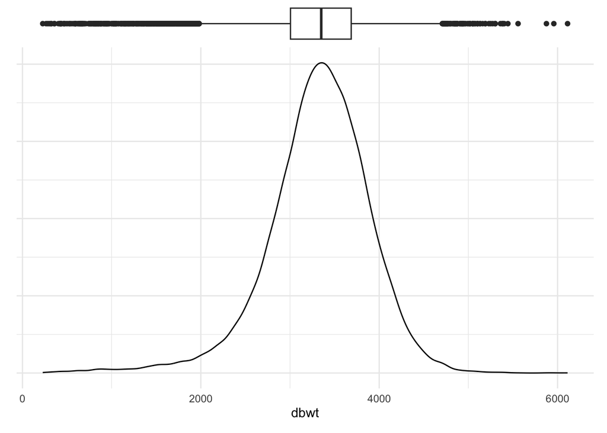